# README

# Data Loading and partition

The code below downloaded the data to a temporary file. Once downloaded, it was read it into R and a 70/30 partition was created to serve as the training and test data sets.

```r
library(caret)
```

```r
# create temp file and dnowload the data to it
temp <- tempfile()
download.file("http://d396qusza40orc.cloudfront.net/predmachlearn/pml-training.csv",temp)
data <- read.csv(file=temp, na.strings=c("NA", ""))

# set seed for reporducibilty and partition the data set
set.seed(1987)
train <- createDataPartition(y=data$classe, p=0.7, list=FALSE)
training <- data[train, ]
test <- data[-train, ]
```

# Initial Exploratory Analysis

A quick check of the outcome variables shows the presence of 5 categories. These are more or less equally represented within the training set.

```r
# xtable package used to make pleasing looking tables
library(xtable)
table <- table(training$classe)
xt <- xtable(table)
print(xt, type="html",include.colnames=FALSE)
```

| A | 3906 |
| --- | --- |
| B | 2658 |
| C | 2396 |
| D | 2252 |
| E | 2525 |

Glancing over the data, it was found that many of the predictor columns were mainly NA values. It was decided that due to the lack of data that these would be removed from the training set.

```r
training <- training[ ,apply(training, 2, function(x) sum(is.na(x)) == 0)]
```

The first 7 columns of the data frame contain tracking details such as time of measurement, name of subject and the window the measurement occurred in. These details should not effect the class and even if it did it would depend on the behavior of the specific subject, so it was decided that these would be removed in order to make a general model.

```r
training <- training[ ,8:ncol(training)]
```

Next a matrix to assess pair-wise correlation was built.

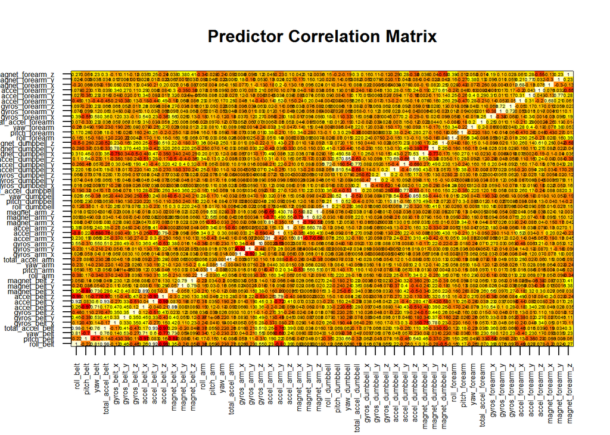

```r
matrix <- cor(training[ ,1:ncol(training)-1])
# plot matrix with 'image' function
image(1:ncol(matrix), 1:ncol(matrix), matrix, xaxt="n", xlab="", yaxt="n", ylab="", main="Predictor Correlation Matrix")
for(i in 1:ncol(matrix)) {
  for(j in 1:nrow(matrix)) {
    text(i,j,labels=format(matrix[i,j], digits=2), cex=0.3)
  }
}
axis(side=1, at=seq(1,ncol(matrix),by=1), labels=colnames(matrix), cex.axis=0.5, las=2)
axis(side=2, at=seq(1, nrow(matrix), by=1), labels=rownames(matrix), cex.axis=0.5, las=2)
```

A number of these are highly correlated. It was decided to remove variables if they were more than 0.9 correlation with another variable.

```r
# identify pairs with >0.9 high correlation
high.corr <- findCorrelation(matrix, cutoff = 0.9)
# remove highly correlated descriptors
training <- training[, -high.corr]
```

# Model construction

Due to the large number of predictors it was decided to build a model based on random forest analysis. In order to speed up the model, the doParallel package was used to detect the additional data cores on the user’s machine.

```r
library("doParallel")
registerDoParallel(cores=detectCores())

model <- train(classe ~ ., data=training, method="rf", trControl = trainControl(method = "cv", number = 4, allowParallel = TRUE))
# print final model
model$finalModel
```

```
##
## Call:
##  randomForest(x = x, y = y, mtry = param$mtry)
##                Type of random forest: classification
##                      Number of trees: 500
## No. of variables tried at each split: 24
##
##         OOB estimate of  error rate: 0.71%
## Confusion matrix:
##      A    B    C    D    E class.error
## A 3902    3    0    0    1    0.001024
## B   27 2623    8    0    0    0.013168
## C    0   11 2375   10    0    0.008765
## D    0    0   19 2229    4    0.010213
## E    0    1    4    9 2511    0.005545
```

# Finding the error in the Model

To find the out-of-sample error, the model was applied to the “test”" dataset created through partitioning earlier. The error was assessed via a confusion matrix. The results are shown below.

```r
confusionMatrix(predict(model,newdata=test), test$classe)
```

```
## Confusion Matrix and Statistics
##
##           Reference
## Prediction    A    B    C    D    E
##          A 1673    9    0    0    0
##          B    0 1127    5    1    0
##          C    0    2 1019   17    0
##          D    0    0    2  945    2
##          E    1    1    0    1 1080
##
## Overall Statistics
##
##                Accuracy : 0.993
##                  95% CI : (0.991, 0.995)
##     No Information Rate : 0.284
##     P-Value [Acc > NIR] : <2e-16
##
##                   Kappa : 0.991
##  Mcnemar's Test P-Value : NA
##
## Statistics by Class:
##
##                      Class: A Class: B Class: C Class: D Class: E
## Sensitivity             0.999    0.989    0.993    0.980    0.998
## Specificity             0.998    0.999    0.996    0.999    0.999
## Pos Pred Value          0.995    0.995    0.982    0.996    0.997
## Neg Pred Value          1.000    0.997    0.999    0.996    1.000
## Prevalence              0.284    0.194    0.174    0.164    0.184
## Detection Rate          0.284    0.192    0.173    0.161    0.184
## Detection Prevalence    0.286    0.193    0.176    0.161    0.184
## Balanced Accuracy       0.999    0.994    0.995    0.990    0.999
```

The accuracy according to the above model is 99.3%. This means that the out-of-sample error can be taken as 0.7%.

# Applying model to the validation cases

Loading the secondary data set from the assignment page and applying the model to each entry correctly identified all 20 cases.

```r
temp <- tempfile()
download.file("http://d396qusza40orc.cloudfront.net/predmachlearn/pml-testing.csv",temp)

validation.cases <- read.csv(file=temp, na.strings=c("NA", ""))

results <- predict(model, newdata=validation.cases)
results.table <- data.frame(results)
rownames(results.table) <- 1:20
xt <- xtable(t(results.table))
print(xt, type="html",include.rownames=FALSE)
```

| 1 | 2 | 3 | 4 | 5 | 6 | 7 | 8 | 9 | 10 | 11 | 12 | 13 | 14 | 15 | 16 | 17 | 18 | 19 | 20 |
| --- | --- | --- | --- | --- | --- | --- | --- | --- | --- | --- | --- | --- | --- | --- | --- | --- | --- | --- | --- |
| B | A | B | A | A | E | D | B | A | A | B | C | B | A | E | E | A | B | B | B |

# Summary

Using a random forest model on the supplied data set, a model with an estimated out-of-sample error rate of 0.7% was constructed. The validation set’s 20 cases were all correctly identified.